# Time Series Forecasting and Analysis Report

Forecasting Framework

2026-06-14

## Executive Summary

This document provides a comprehensive analysis and forecast of the time series dataset loaded from `data/daily-total-female-births.csv`.

The analysis steps include: 1. Data cleaning and preparation. 2. Exploratory time series analysis (stationarity, decomposition, autocorrelation). 3. Model fitting (Seasonal Naive, ETS, Holt-Winters, and Auto-ARIMA). 4. Validation and error metrics evaluation against a test holdout set. 5. Statistical diagnostics of residuals. 6. Multi-step ahead forecasting.

## 1. Data Exploration & Quality Checks

```r
# Ensure data is present
if (params$data_path == "data/daily-total-female-births.csv") {
  download_default_data(params$data_path)
}
```

```
## [1] TRUE
```

```r
raw_df <- load_and_clean_data(params$data_path)
y <- create_ts_object(raw_df, frequency = params$frequency)

# Basic statistics
summary_stats <- summary(y)
```

The time series contains 365 observations. Below is the statistical summary of the values:

Time Series Descriptive Statistics

| Min | 1st Qu. | Median | Mean | 3rd Qu. | Max |
| --- | --- | --- | --- | --- | --- |
| 23 | 37 | 42 | 41.98082 | 46 | 73 |

### 1.1 Visualizing the Time Series

The raw observations plotted over time to check for trends, seasonality, or obvious outliers:

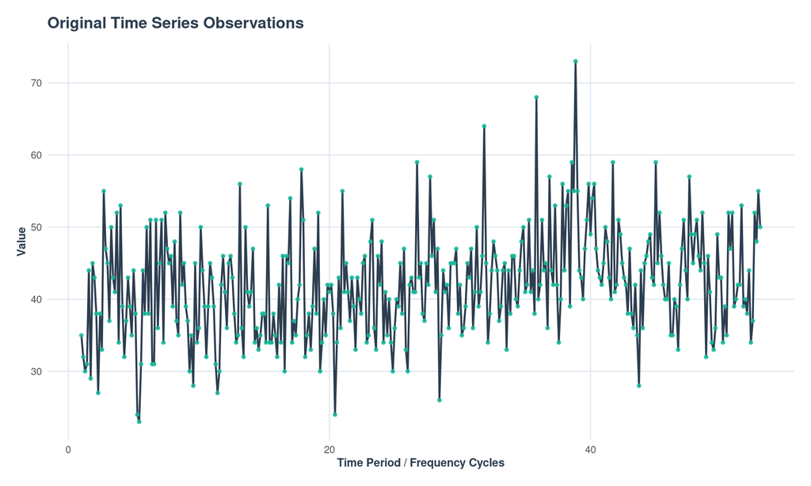

### 1.2 Stationarity Test

We perform the Augmented Dickey-Fuller (ADF) test to evaluate if the series is stationary. - **Null Hypothesis ($H_0$):** The series has a unit root (is non-stationary). - **Alternative Hypothesis ($H_a$):** The series is stationary.

```r
adf_res <- adf.test(y)
```

The ADF statistic is **-5.1042** with a p-value of **0.01**. Since the p-value is less than 0.05, we reject the null hypothesis and conclude that the series is **stationary**.

### 1.3 Time Series Decomposition

Applying Seasonal and Trend decomposition using LOESS (STL) to separate the series into its underlying component parts: trend, weekly seasonal pattern, and residual noise.

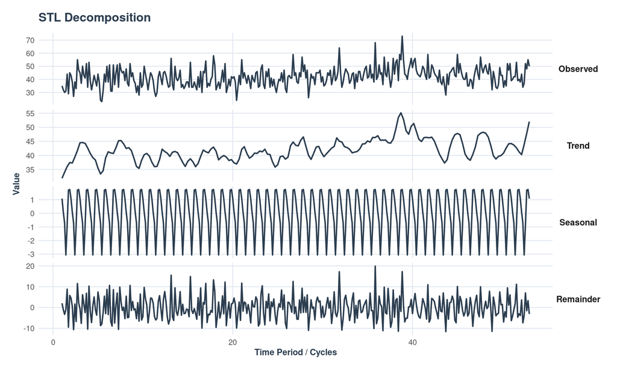

## 2. Model Fitting and Evaluation

We split the dataset into training and test holdout sets using a split ratio of 70%. - **Training Set Size:** 255 observations. - **Test Set Size (Forecast Horizon $h$):** 110 observations.

```r
split <- split_train_test(y, train_ratio = params$train_ratio)
train <- split$train
test <- split$test
h <- split$h
```

We fit four forecasting models to the training data: 1. **Seasonal Naive (SNAIVE):** Projects the last observed seasonal cycle forward. 2. **ETS (Error, Trend, Seasonal):** State space exponential smoothing model. 3. **Holt-Winters (HW):** Triple exponential smoothing. 4. **Auto-ARIMA (ARIMA):** Automated Box-Jenkins modeling.

```r
fc_snaive <- fit_snaive_model(train, h = h)
fc_ets <- fit_ets_model(train, h = h)
fc_hw <- fit_holtwinters_model(train, h = h, seasonal = "additive")
fc_arima <- fit_arima_model(train, h = h)
```

### 2.1 Model Comparison & Accuracy Metrics

We compute the prediction errors on the test dataset.

Model Accuracy Comparison on Test Holdout Set

|  | ME | RMSE | MAE | MPE | MAPE | MASE |
| --- | --- | --- | --- | --- | --- | --- |
| SNAIVE | -1.118 | 9.514 | 7.627 | -5.062 | 17.745 | 1.049 |
| ETS | 1.087 | 7.277 | 5.681 | -0.007 | 12.737 | 0.781 |
| HoltWinters | -7.934 | 12.166 | 9.995 | -21.016 | 24.601 | 1.375 |
| ARIMA | 0.790 | 7.262 | 5.602 | -0.772 | 12.620 | 0.771 |

### 2.2 Forecast Plots

The following sections plot the forecasts against the actual test values:

### 2.2.1 Seasonal Naive Forecast

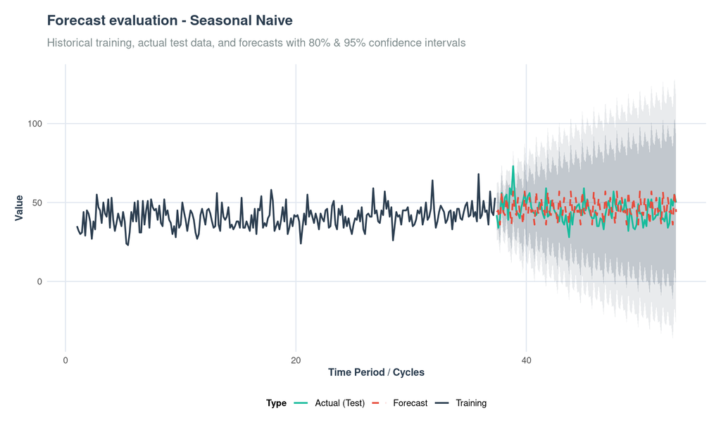

### 2.2.2 ETS Forecast

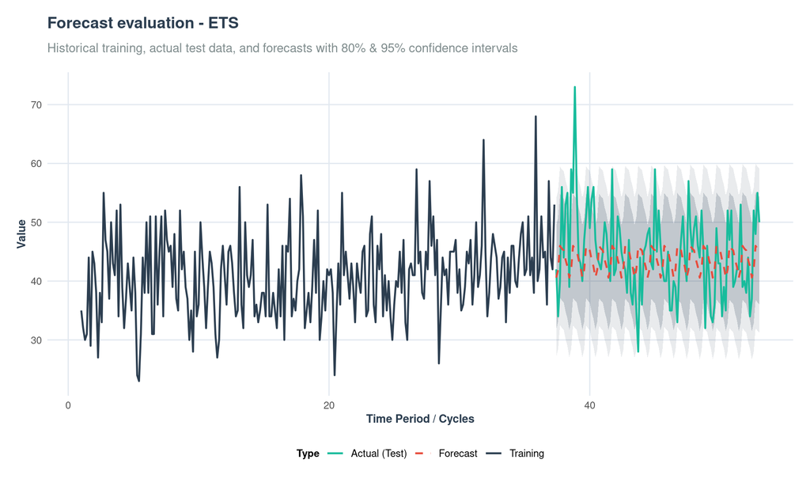

### 2.2.3 Holt-Winters Forecast

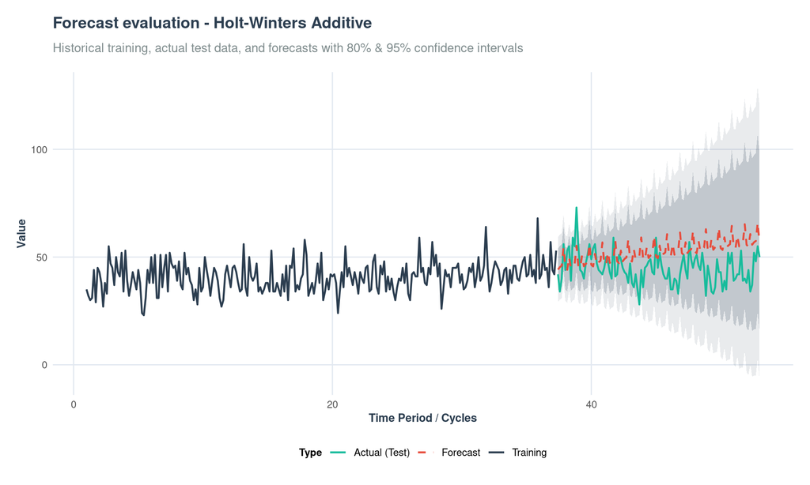

### 2.2.4 Auto-ARIMA Forecast

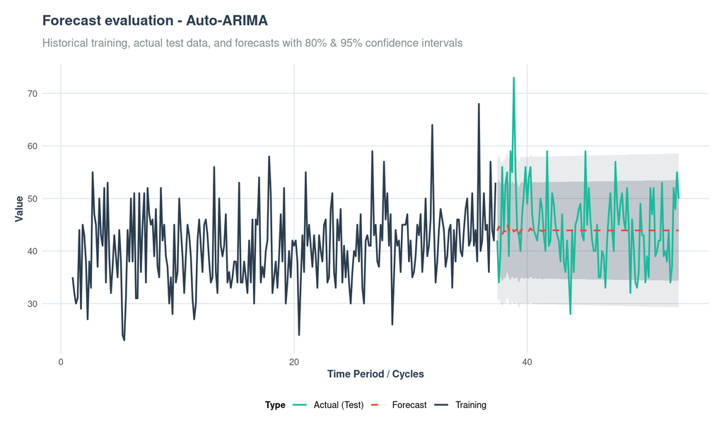

## 3. Residual Diagnostics (Auto-ARIMA)

A good model should have residuals that resemble white noise (uncorrelated, zero mean, constant variance). We examine the residuals of the Auto-ARIMA model.

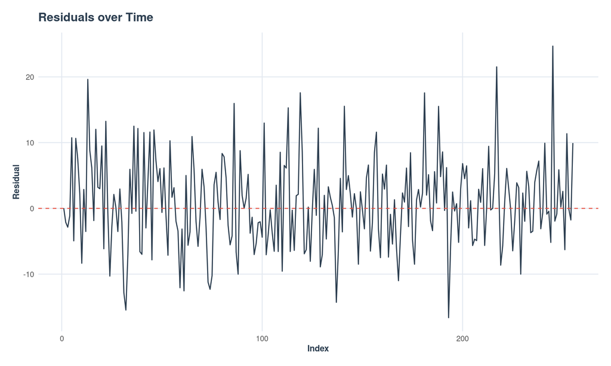

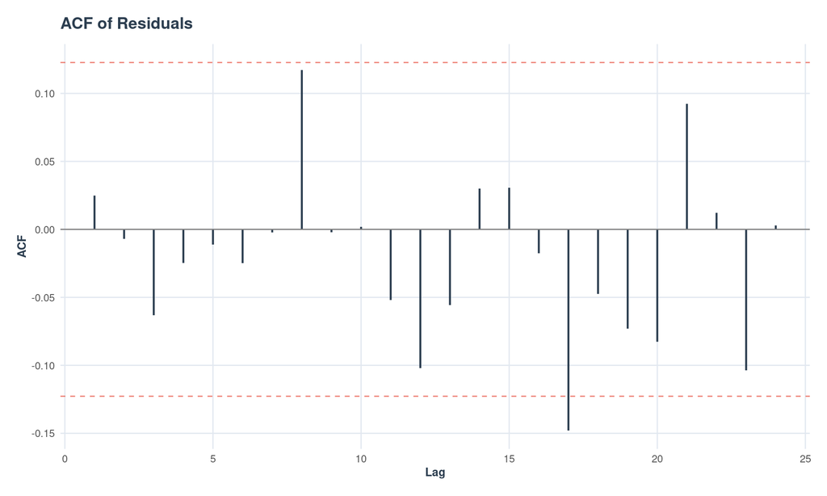

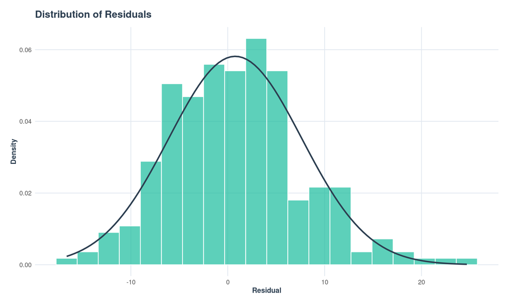

### 3.1 Portmanteau Test (Ljung-Box)

We run a Ljung-Box test to check if the residuals have significant autocorrelations. - **Null Hypothesis ($H_0$):** Residuals are independent (no autocorrelation, white noise). - **Alternative Hypothesis ($H_a$):** Residuals exhibit autocorrelation.

```r
lb_test <- Box.test(residuals(fc_arima$model), lag = params$frequency * 2, type = "Ljung-Box")
lb_test
```

```
##
##  Box-Ljung test
##
## data:  residuals(fc_arima$model)
## X-squared = 9.8282, df = 14, p-value = 0.7746
```

The Ljung-Box test p-value is **0.7746**. Since the p-value is greater than 0.05, we fail to reject the null hypothesis, indicating that the residuals are **uncorrelated** and consistent with white noise.

## 4. Final Forecast

Based on the metrics above, the best-performing model can be selected. The following table displays the final forecast points and confidence bands for the upcoming 30 time periods.

First 15 Steps of Final Model Forecast Predictions

| Point_Forecast | Lo_80 | Hi_80 | Lo_95 | Hi_95 |
| --- | --- | --- | --- | --- |
| 44.42 | 35.55 | 53.29 | 30.85 | 57.99 |
| 42.26 | 33.29 | 51.24 | 28.53 | 55.99 |
| 42.07 | 33.08 | 51.05 | 28.33 | 55.81 |
| 47.12 | 38.13 | 56.11 | 33.37 | 60.87 |
| 44.13 | 35.14 | 53.12 | 30.38 | 57.88 |
| 45.15 | 36.15 | 54.14 | 31.39 | 58.90 |
| 45.50 | 36.51 | 54.50 | 31.74 | 59.27 |
| 43.45 | 34.32 | 52.58 | 29.48 | 57.41 |
| 42.96 | 33.82 | 52.10 | 28.98 | 56.94 |
| 42.56 | 33.42 | 51.71 | 28.58 | 56.55 |
| 43.98 | 34.83 | 53.13 | 29.98 | 57.97 |
| 43.91 | 34.76 | 53.06 | 29.91 | 57.91 |
| 43.89 | 34.73 | 53.05 | 29.88 | 57.90 |
| 42.93 | 33.77 | 52.09 | 28.92 | 56.94 |
| 43.54 | 34.36 | 52.71 | 29.51 | 57.56 |